# Class 13: Visualizing Campaign Finance data

## Instructions

Today in class we will begin exploring the campaign finance reports of Gov. Roy Cooper. For homework —- in preparation for your final report – you will do the same analysis for your candidate.

### Load the tidyverse package(s)

```r
#install.packages("tidyverse")
library(tidyverse)
library(lubridate)
library(scales)
```

### Load the data

```r
url <- "https://cf.ncsbe.gov/CFOrgLkup/ExportDetailResults/?ReportID=172102&Type=REC&Title=Cooper%20for%20North%20Carolina%20-%202019%20Year%20End%20Semi-Annual"

#read_csv() does not do a great job here guessing the correct col_types, so we have to define them explicitly.

cooper_rcpts_2019A <- read_csv(url,
    col_types = cols(
      `Account Abbr` = col_character(),
        City = col_character(),
      `Country Name` = col_character(),
        Date = col_date(format = "%m/%d/%Y"),
        Description = col_character(),
      `Employers Name` = col_character(),
        `Full Zip` = col_character(),
      `Outside US Postal Code` = col_character(),
        Profession = col_character(),
      Purpose = col_character(),
        State = col_character(),
      `Street 1` = col_character(),
        `Street 2` = col_character()),
    skip = 1)

#Finally, we should rename the columns to remove spaces and generally promote brevity.

names(cooper_rcpts_2019A) <- c("date","prior","donor","street1","street2","city","state","zip","country","postal","profession","employer","purpose","type","account","payment_form","description","amount","sum_to_date")
```

#One Numeric Variable

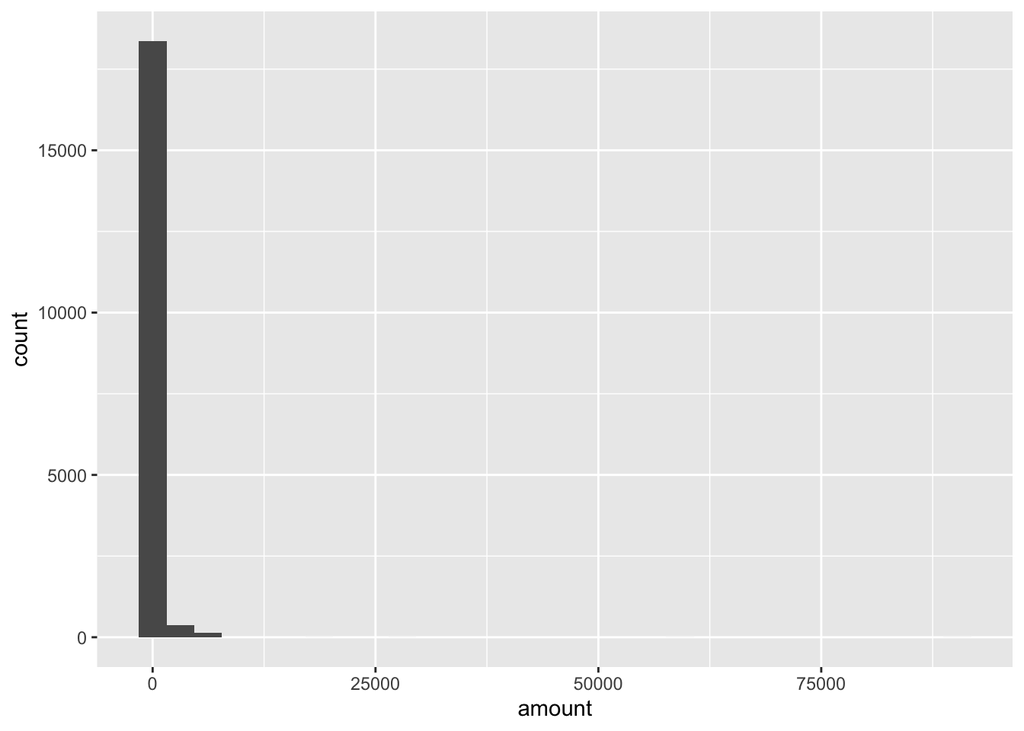

```r
cooper_rcpts_2019A %>%
  ggplot(mapping = aes(x = amount)) +
  geom_histogram()
```

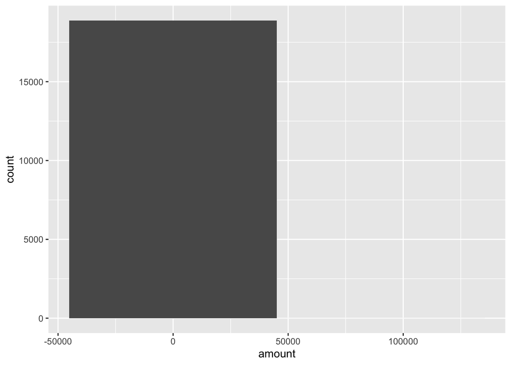

```r
cooper_rcpts_2019A %>%
  ggplot(mapping = aes(x = amount)) +
  geom_histogram(bins = 2)
```

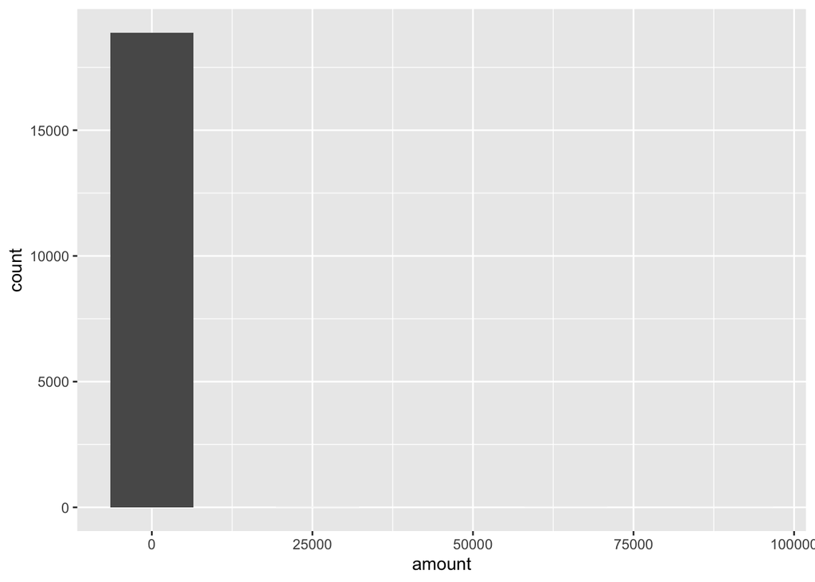

```r
cooper_rcpts_2019A %>%
  ggplot(mapping = aes(x = amount)) +
  geom_histogram(bins = 8)
```

```r
cooper_rcpts_2019A %>%
  filter(amount > 5400)
```

```
## # A tibble: 4 x 19
##   date       prior donor street1 street2 city  state zip   country postal
##   <date>     <lgl> <chr> <chr>   <chr>   <chr> <chr> <chr> <chr>   <chr>
## 1 2019-12-31 NA    NC D… 434 FA… <NA>    RALE… NC    27601 United… <NA>
## 2 2019-12-31 NA    NC D… 434 FA… <NA>    RALE… NC    27601 United… <NA>
## 3 2019-12-31 NA    NC D… 434 FA… <NA>    RALE… NC    27601 United… <NA>
## 4 2019-12-31 NA    NC D… 434 FA… <NA>    RALE… NC    27601 United… <NA>
## # … with 9 more variables: profession <chr>, employer <chr>, purpose <chr>,
## #   type <chr>, account <chr>, payment_form <chr>, description <chr>,
## #   amount <dbl>, sum_to_date <dbl>
```

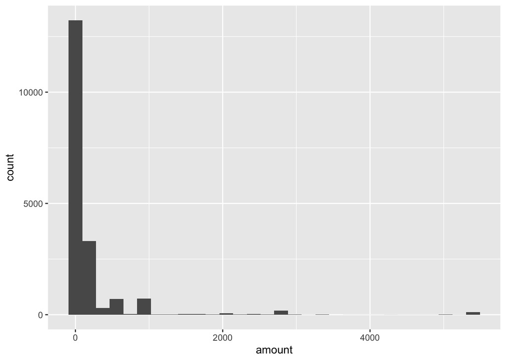

```r
cooper_rcpts_2019A %>%
  filter(amount <= 5400) %>%
  ggplot(mapping = aes(x = amount)) +
  geom_histogram()
```

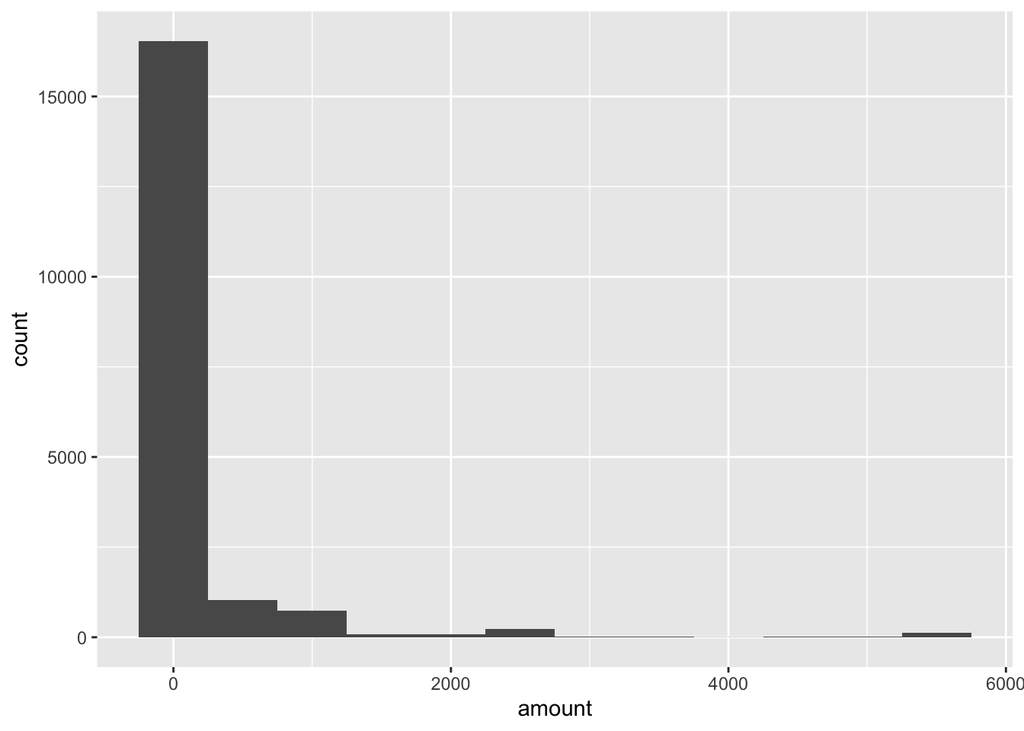

```r
cooper_rcpts_2019A %>%
  filter(amount <= 5400) %>%
  ggplot(mapping = aes(x = amount)) +
  geom_histogram(binwidth=500)
```

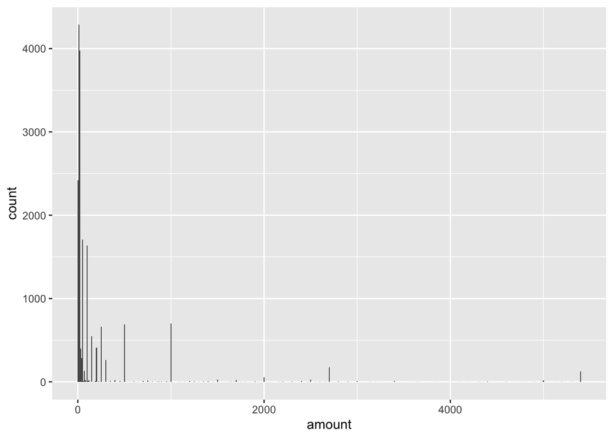

```r
cooper_rcpts_2019A %>%
  filter(amount <= 5400) %>%
  ggplot(mapping = aes(x = amount)) +
  geom_histogram(binwidth=10)
```

### Extra credit: Add a new layer called scale_x_continuous to make it a little bit easier to interpret these granular results

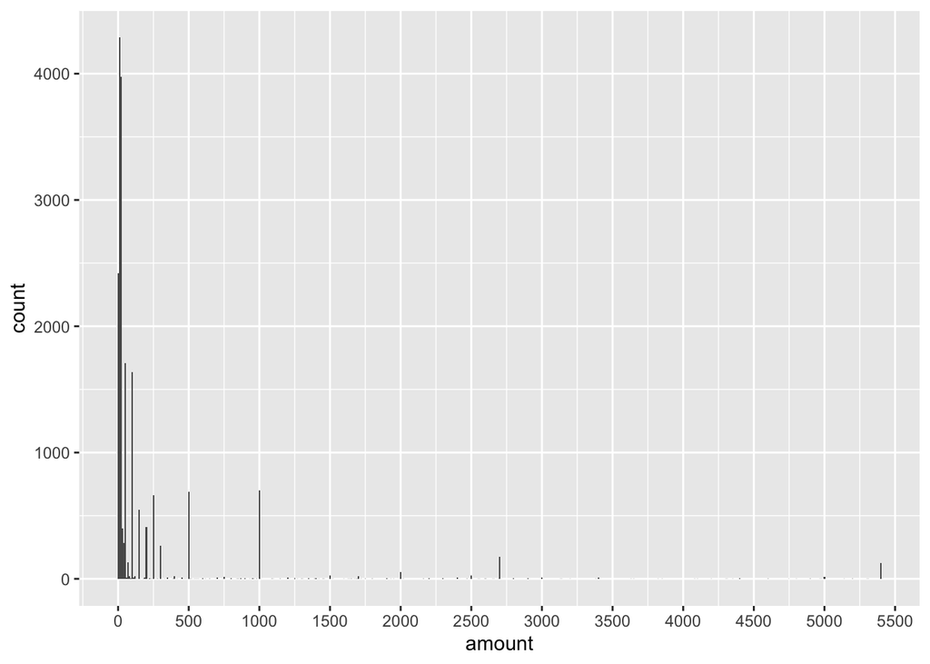

```r
cooper_rcpts_2019A %>%
  filter(amount <= 5400) %>%
  ggplot(mapping = aes(x = amount)) +
  geom_histogram(binwidth=10) +
  scale_x_continuous(breaks = seq(0, 5500, 500))
```

### From Cooper’s perspective, what are “Small”, “medium”, “large” donations?

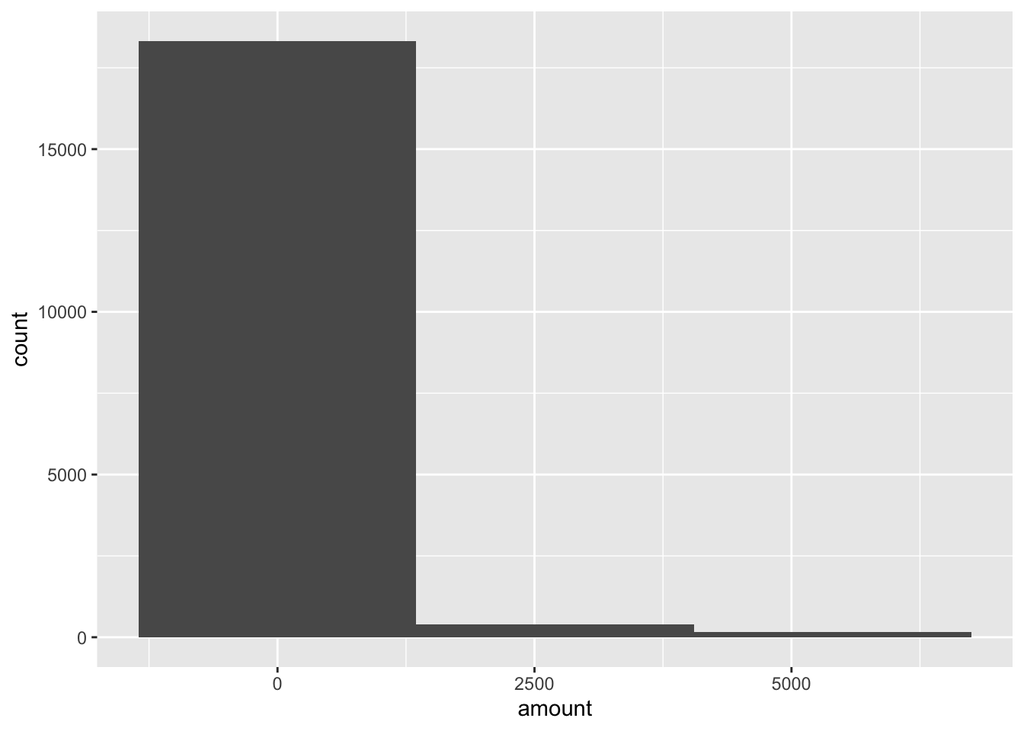

```r
cooper_rcpts_2019A %>%
  filter(amount <= 5400) %>%
  ggplot(mapping = aes(x = amount)) +
  geom_histogram(bins = 3)
```

### Comparing number of donations by type.

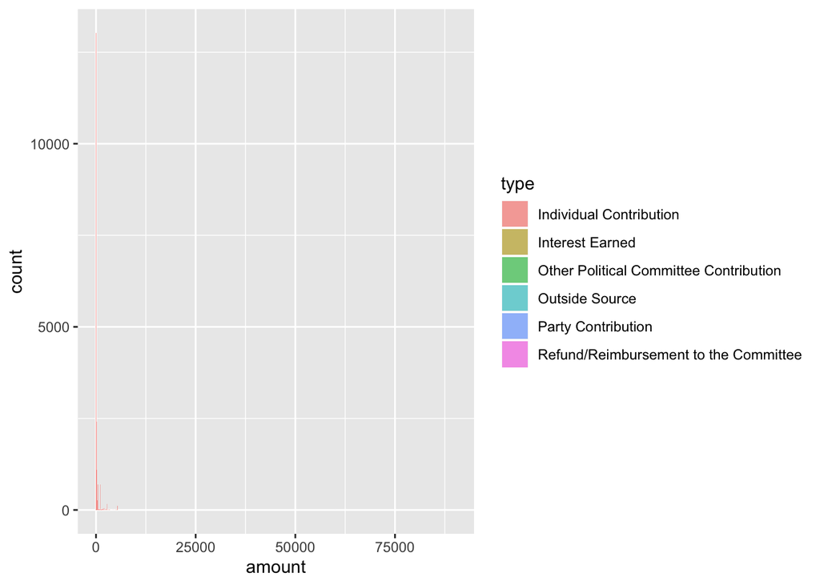

```r
cooper_rcpts_2019A %>%
  ggplot(mapping = aes(x=amount, fill=type)) +
  geom_histogram(alpha=0.6, position = 'identity', binwidth = 100)
```

### By profession.

This is what you should do, but it will cause choking. Why? Because there are too many professions. But notice that even the “choking” reveals an insight.

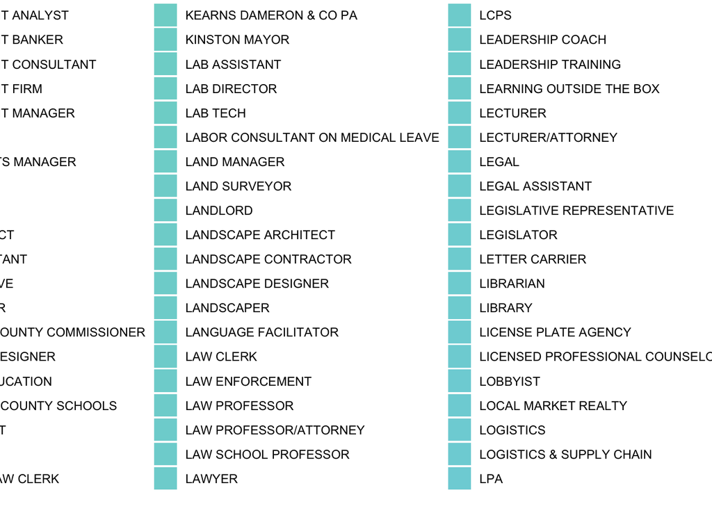

```r
cooper_rcpts_2019A %>%
  filter(amount <= 5400) %>%
  ggplot(mapping = aes(x=amount, fill=profession)) +
  geom_histogram(alpha=0.6, position = 'identity', binwidth = 100)
```

### By state. Also not super useful

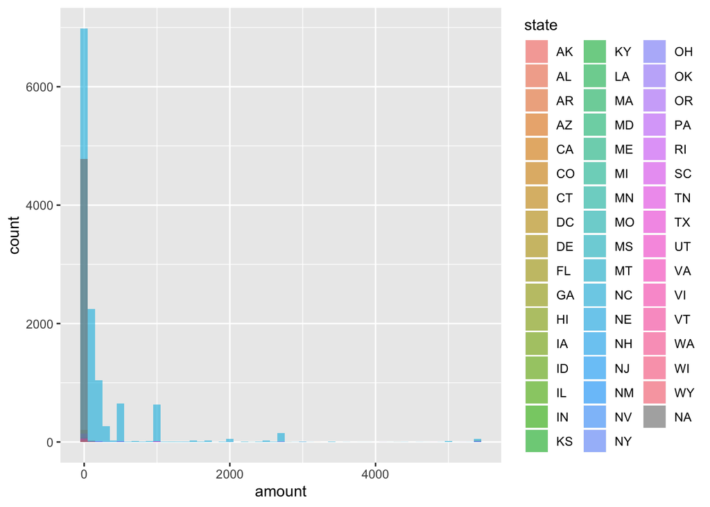

```r
cooper_rcpts_2019A %>%
  filter(amount <= 5400) %>%
  ggplot(mapping = aes(x=amount, fill=state)) +
  geom_histogram(alpha=0.6, position = 'identity', binwidth = 100)
```

### Also with one numeric variable, density plot

This shows you proportion, rather than raw count.

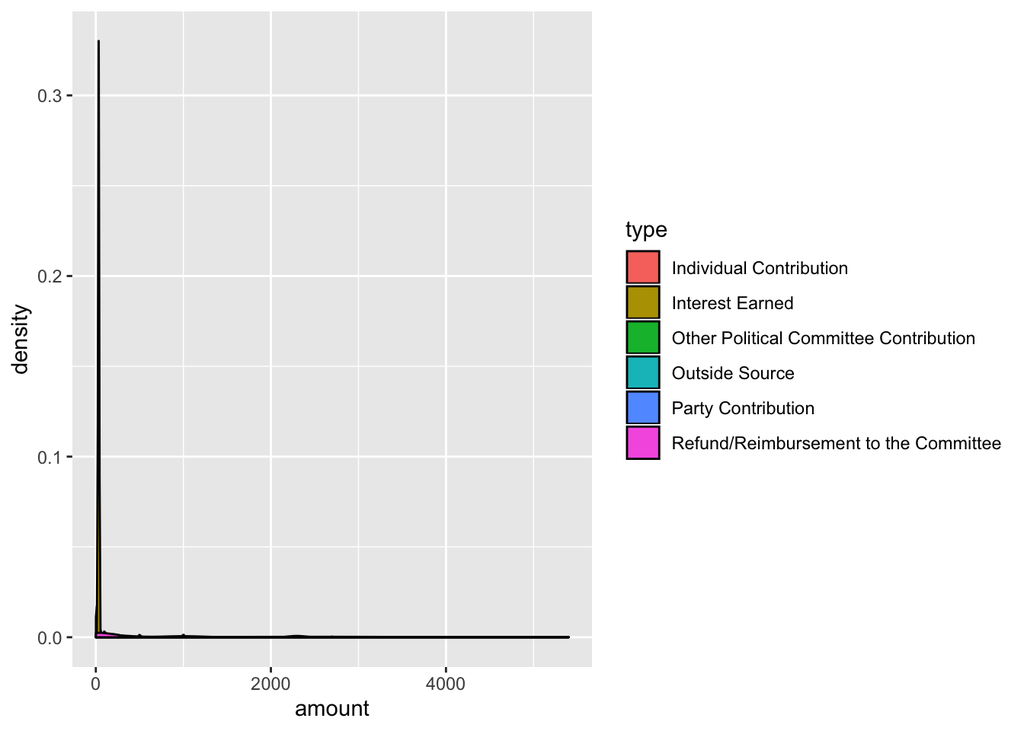

```r
cooper_rcpts_2019A %>%
  filter(amount <= 5400) %>%
  ggplot(mapping = aes(x = amount, fill = type)) +
  geom_density()
```

### Zoom with coord_cartesian()

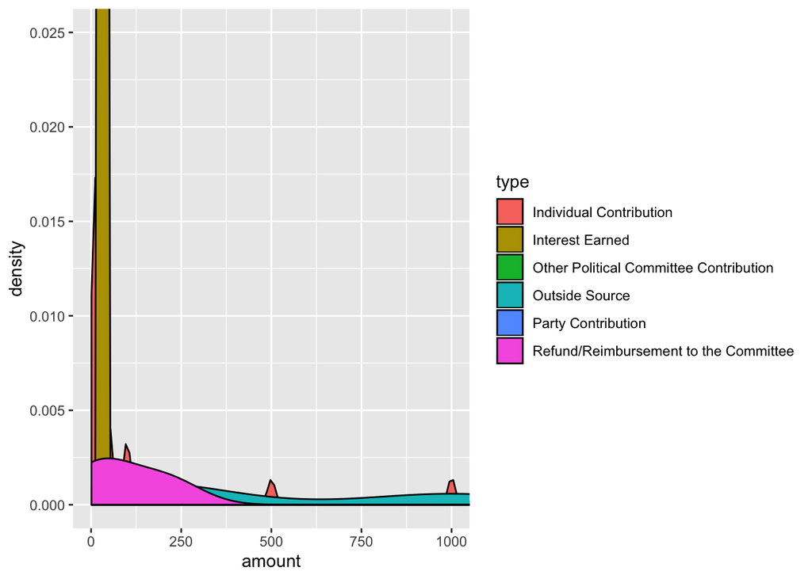

```r
cooper_rcpts_2019A %>%
  filter(amount <= 5400) %>%
  ggplot(mapping = aes(x = amount, fill = type)) +
  geom_density() +
  coord_cartesian(xlim=c(0,1000), ylim = c(0,.025))
```

### Extra Credit

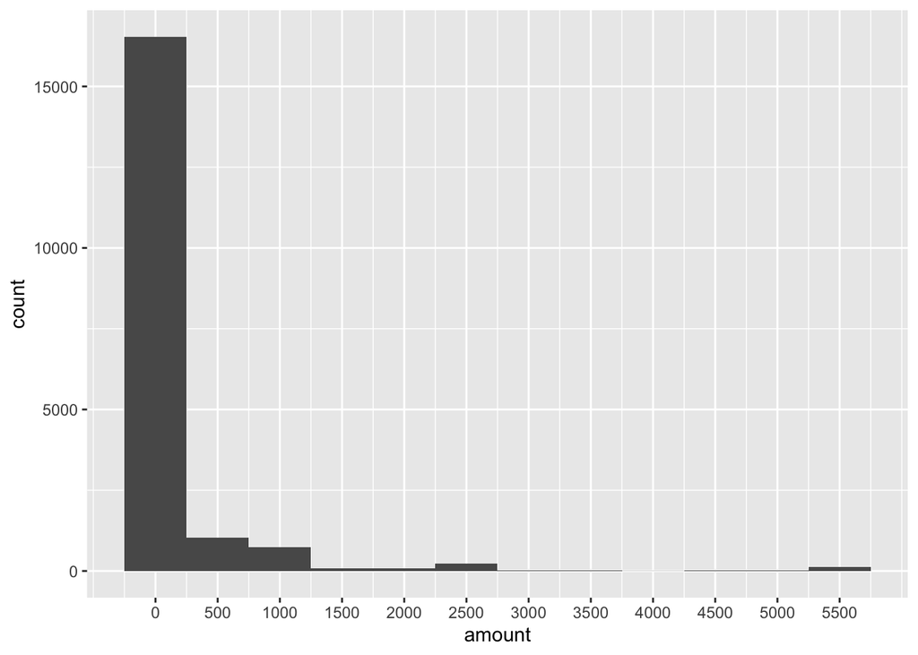

```r
cooper_rcpts_2019A %>%
  filter(amount <= 5400) %>%
  ggplot(mapping = aes(x = amount)) +
  geom_histogram(binwidth=500) +
  scale_x_continuous(breaks = seq(0, 5500, 500))
```

## Two numeric values

We don’t really have this here. An example of this would be voter registration by precinct. So you would have the number of voters, etc.

## One categorical variable.

This really only works with grouped. Check out the difference between these two bars that at first blush look the same, but really are different.

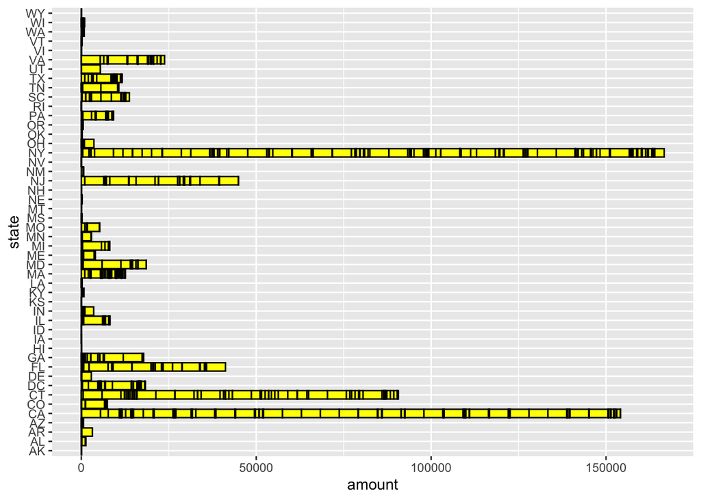

```r
cooper_rcpts_2019A %>%
  filter(state != "NC") %>%
ggplot(aes(x=state, y=amount)) +
  geom_bar(stat = "identity", color = "black", fill="yellow") +
  coord_flip()
```

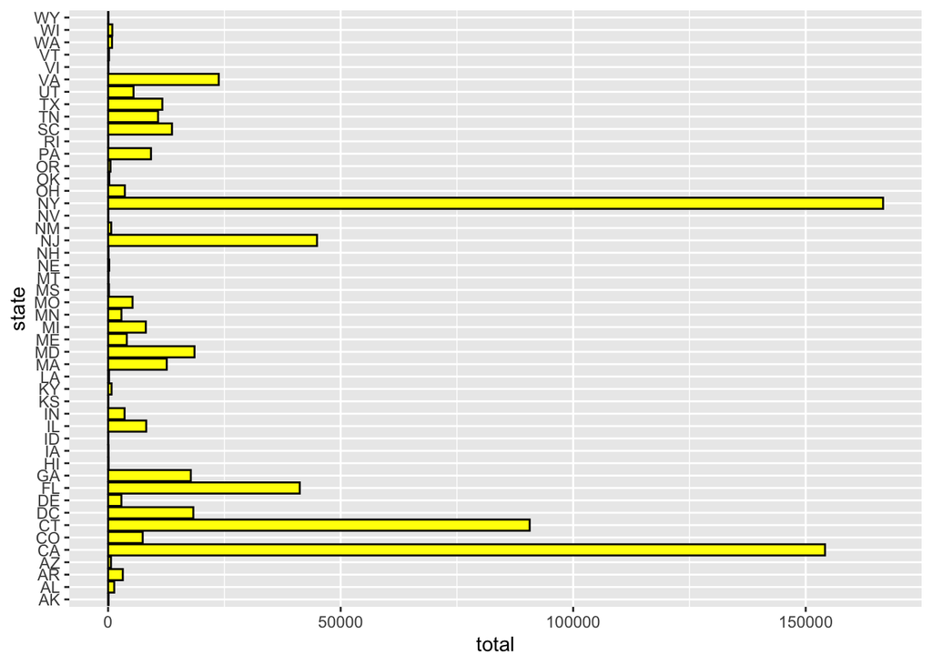

```r
cooper_rcpts_2019A %>%
  filter(state != "NC") %>%
  group_by(state) %>%
  summarise(total = sum(amount)) %>%
ggplot(aes(x=state, y=total)) +
  geom_bar(stat = "identity", color="black", fill="yellow") +
  coord_flip()
```

An example with months …

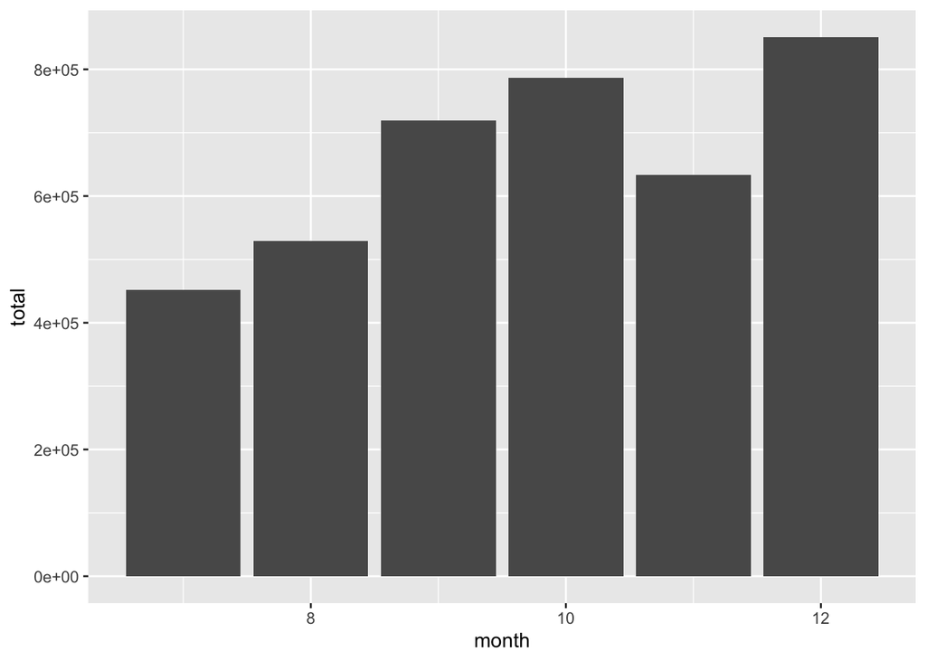

```r
cooper_rcpts_2019A %>%
  group_by(month = month(date)) %>%
  summarise(total = sum(amount)) %>%
ggplot(aes(x=month, y=total)) +
  geom_bar(stat = "identity")
```

### Comparing one numeric value across multiple categorical variables

These stacked bars let us look at both month *and* type.

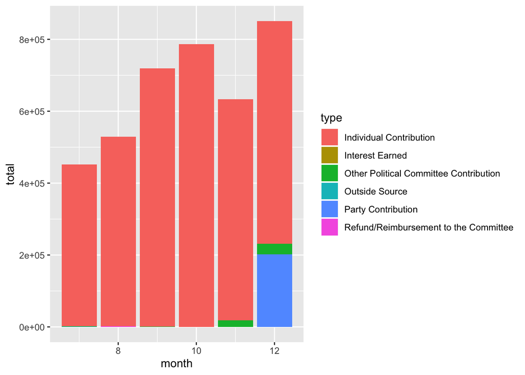

```r
cooper_rcpts_2019A %>%
  group_by(month = month(date), type) %>%
  summarise(total = sum(amount)) %>%
ggplot(aes(x=month, y=total, fill = type)) +
  geom_bar(stat = "identity")
```

This is the same, but with side-by-side bars

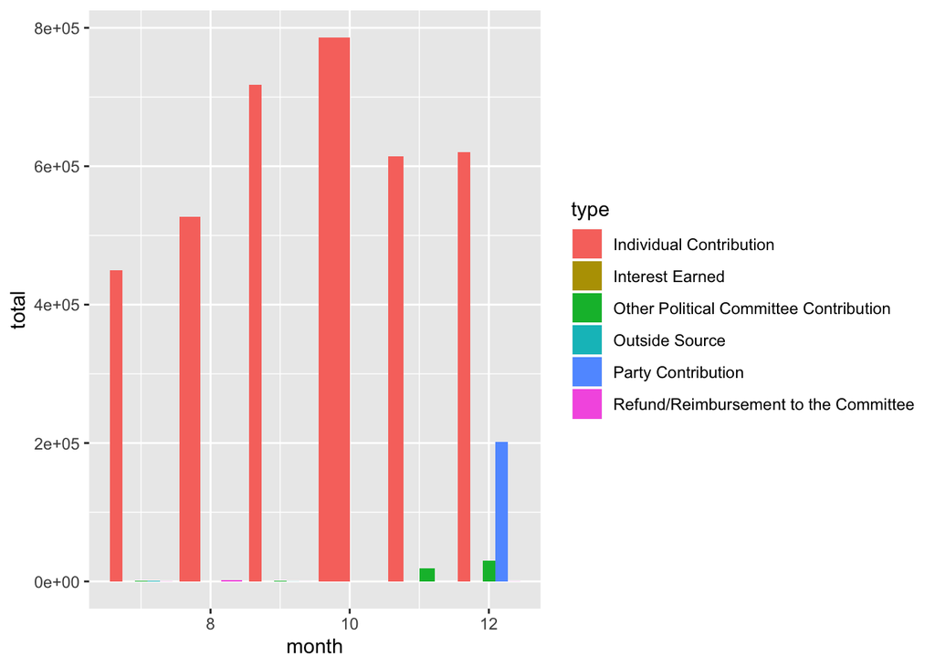

```r
cooper_rcpts_2019A %>%
  group_by(month = month(date), type) %>%
  summarise(total = sum(amount)) %>%
ggplot(aes(x=month, y=total, fill = type)) +
  geom_bar(stat = "identity", position="dodge")
```

###Stacked area graph

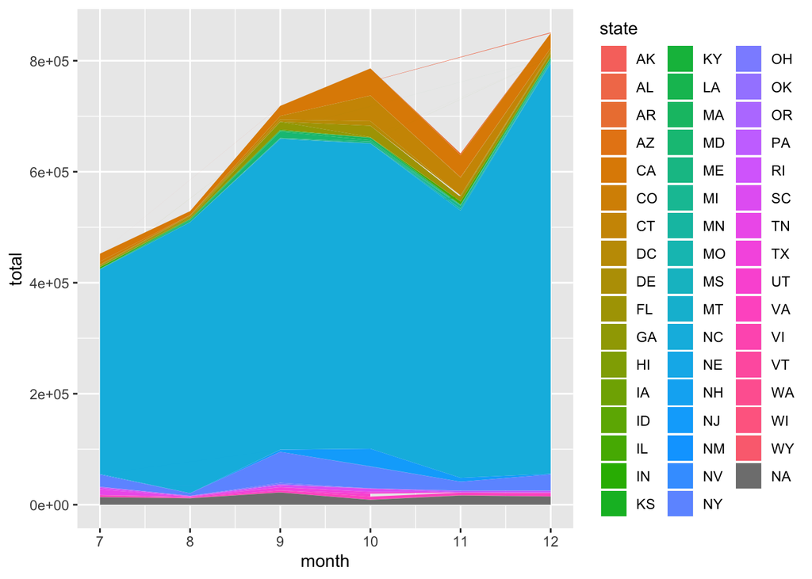

```r
cooper_rcpts_2019A %>%
  group_by(state, month = month(date)) %>%
  summarise(total = sum(amount)) %>%
  ggplot(aes(x=month, y=total, fill=state)) +
 geom_area()
```

### Boxplot by month

What does this show ? A ton of huge outliers every month.

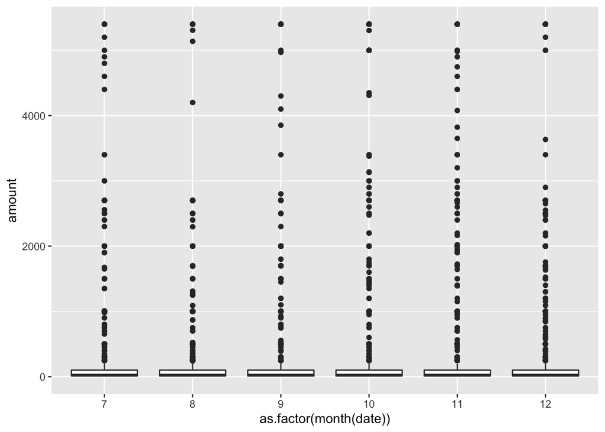

```r
cooper_rcpts_2019A %>%
  filter(amount <= 5400) %>%
  # We use as.factor() to turn a continuous variable into a categorical variable.
  ggplot(mapping = aes(x = as.factor(month(date)), y = amount)) +
  geom_boxplot()
```

### Kind of like those crosstabs we built.

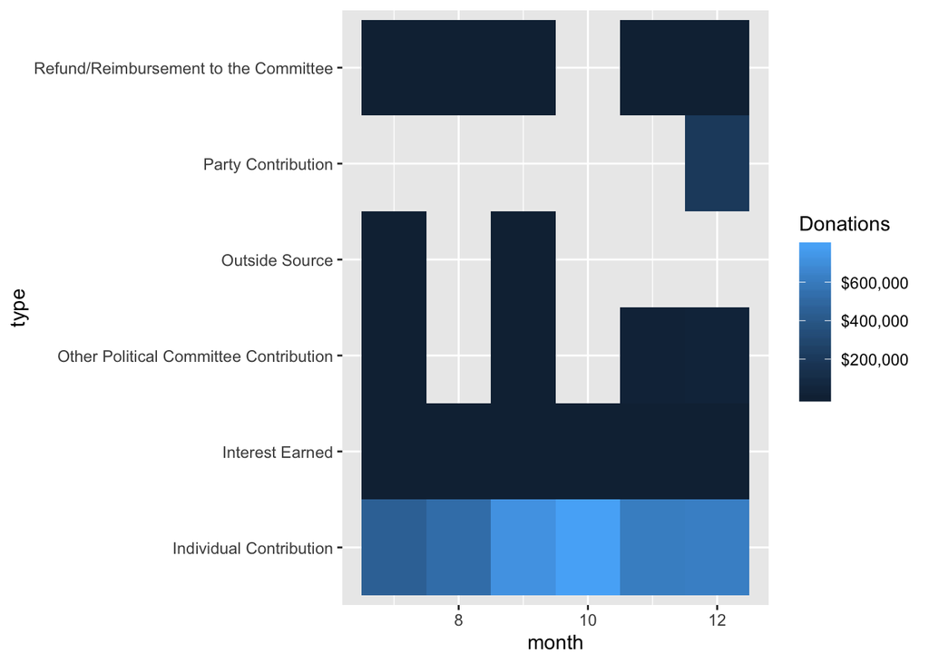

```r
cooper_rcpts_2019A %>%
    group_by(type, month = month(date)) %>%
  summarise(total = sum(amount)) %>%
  ggplot(mapping = aes(x = month, y = type)) +
    geom_tile(mapping = aes(fill = total)) +
    scale_fill_continuous(name="Donations", labels = dollar_format())
```